# Milestone 4 – KM

Write a short blog post (no more than 1000 words) about your results so far. Create a Milestone3-Blog.qmd file in your results folder within project repository on Github and render to generate an HTML file for this post. In this post, you should:

# Motivate the importance of the topic (166 words)

The Macalester Women’s Volleyball team, as with most point-oriented sports teams at Mac, has employees at their matches collecting game statistics. However, much of the time, these game statistics just sit around in a database or are used for a few basic calculations by the coaching staff to evaluate performance. This project aims to use these statistics to create insights into the team’s performance and development. This is important for a team because it can help the coaches and players understand their strengths and weaknesses and help them improve their performance by alerting them what aspects of play that could be paid more attention to in practice.

While sports analytics is a well-established field in professional and D1 sports, it is not as common in the context of small, liberal arts college sports teams, especially women’s sports teams. This project aims to bridge that gap by providing a detailed analysis of the Macalester Women’s Volleyball that aims to answer data questions from the coaching staff themselves.

# Lead the reader through the rationale for the narrowing/focusing of the scope via the main 2-3 broad questions

## Q1: modeling w/l based on desired game stats (118 words)

We met with Mac Volleyball head coach Mary Johnston and assistant coach Keelin Severtson in October to discuss the direction that they thought would be most useful for them for us to take with our open-ended project. They expressed interest in understanding their team’s performance (Win/Loss) based on specific game statistics. Specifically, they were curious about relationships between hitting percentage ((total kills - total errors) / total attempts), service aces (Mac serves that were not returned by the opposing team), and service errors (Mac serves that did not land in bounds). This led us to the first broad question of our project: “Can we predict the outcome of a game based on hitting percentage, service aces, and service errors?”

# Tie results (plots and modeling output) to the broad questions and explain how all results fit together

## Q1: modeling w/l based on desired game stats (391 words)

In order to predict the outcome of a game based on hitting percentage, service aces, and service errors, we first needed to clean and preprocess the data. We decided to use data from the 2021, 2022, and 2023 seasons to train our model. We chose these years because 2025 seniors were freshmen for the 2021 season, so these years encompass their entire time at Macalester. Additionally, data from years before 2021 would represent a completely different group of players, and Mary Johnston became the head coach of the team during the 2021 season.

Using this publically available data from the Macalester Athletics website, we were able to train a logistic regression model to predict the outcome of a game based on hitting percentage, service aces, and service errors.

```r
# 2021-2023 Macalester Women's Volleyball Logistic Model (W/L ~ PCT + SA + SE)
logistic_model %>%
  tidy()
```

```
# A tibble: 4 × 5
  term        estimate std.error statistic  p.value
  <chr>          <dbl>     <dbl>     <dbl>    <dbl>
1 (Intercept)  -5.60       1.46     -3.84  0.000123
2 PCT          19.6        5.81      3.38  0.000738
3 SA            0.335      0.129     2.61  0.00906
4 SE            0.0856     0.117     0.735 0.462
```

Looking at the in-sample confusion plot gives us an insight as to how accurate the model performs on the training data, the data from 2021-2023. The squares in the upper left and lower right corners of the plot represent cases where the model *correctly* predicted the outcome of the game.

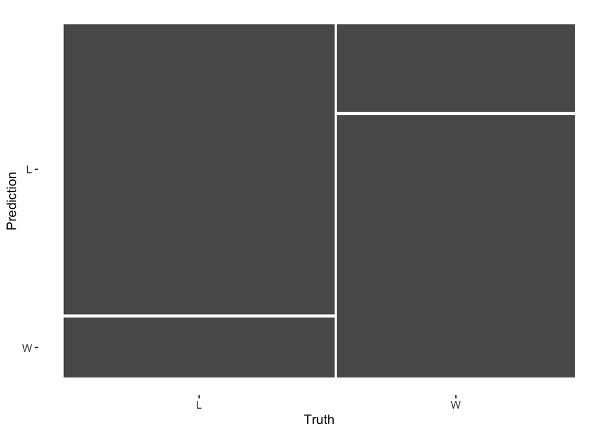

```r
in_sample_confusion %>%
  autoplot()
```

Our model has an in-sample accuracy of 79.2%, meaning that it correctly predicted the outcome of a game used to train it (2021-2023) 79.2% of the time.

```r
summary(in_sample_confusion, event_level = "second") %>%
  filter(.metric == "accuracy")
```

```
# A tibble: 1 × 3
  .metric  .estimator .estimate
  <chr>    <chr>          <dbl>
1 accuracy binary         0.792
```

```r
predictions24 %>%
  group_by(Match) %>%
  summarize(count = n())
```

```
# A tibble: 2 × 2
  Match count
  <lgl> <int>
1 FALSE     9
2 TRUE     21
```

# VIZ FOR 11/12 CLASS

```r
library(tidyverse)
library(rgl)

# COMBINING IN-SAMPLE AND 2024 PREDICTIONS, ASSIGNING COLORS TO THE 4 CATEGORIES OF POINTS
predictions <- predictions24 %>%
  rbind(in_sample_classifications) %>%
  filter(SA < 20) %>% # excludes end-of-season totals (that I forgot to remove earlier)
  mutate(color = case_when(
    Match == TRUE & `W/L` == "W" ~ "darkgreen",
    Match == TRUE & `W/L` == "L" ~ "firebrick2",
    Match == FALSE & `W/L` == "W" ~ "#5e7454",
    Match == FALSE & `W/L` == "L" ~ "#ba6456"
  ))

# SCATTERPLOT
plot3d(x = predictions$PCT, y = predictions$SA, z = predictions$SE, xlab = "Hitting Percentage ((total kills - total errors) / total attempts)", ylab = "Service Aces", zlab = "Service Errors", col = predictions$color, size = 7)

# ADDING TITLE TO BOTTOM OF PLOT
mtext3d("Logistic Model Predictions (W/L) for 2021-2024 Macalester Women's Volleyball Matches", edge = "x--", line = 2)


# MAKING THE LEGEND
points3d(x = 0.3, y = 0, z = 4, col = "darkgreen", size = 10)
points3d(x = 0.3, y = 0, z = 3, col = "firebrick2", size = 10)
points3d(x = 0.3, y = 0, z = 2, col = "#5e7454", size = 10)
points3d(x = 0.3, y = 0, z = 1, col = "#ba6456", size = 10)
text3d(x = 0.3, y = 0, z = 4, texts = "win, win predicted", cex = 1, adj = -.1)
text3d(x = 0.3, y = 0, z = 3, texts = "loss, loss predicted", cex = 1, adj = -.1)
text3d(x = 0.3, y = 0, z = 2, texts = "win, loss predicted", cex = 1, adj = -.1)
text3d(x = 0.3, y = 0, z = 1, texts = "loss, win predicted", cex = 1, adj = -.1)
```

> The plot doesn’t render in html but trust me if you’re reading this, it’s awesome

## FEEDBACK FROM IN CLASS PRESENTATION (11/12)

- change colors – don’t make red/green bc of colorblindness, make more obvious the difference between the dark and more grayed out colors
- improve legend – works well when you’re looking at it head on but not once you start rotating the plot
- for the model, instead of SA and SE for example, change them into a ratio of SA/total serves and SE/total serves to control a little bit for longer games (5 sets vs 3 sets) (have all the axes be %s)
- make a shiny app? it could be cool to be able to add/remove years of data (as it is right now, it’s all of the games combined) or be able to filter wins/losses
- change up the variables in the model – maybe run LOESS to pick out the most important variables? if that’s legal. focus on 3 or 4 maybe – especially if the purpose of this is to help the coaches understand what they should focus on in practice
- **KEEP VARIABLES THE WAY THEY ARE FOR THIS MODEL/VIZ** and try making another! keep this one because it’s what the coaches were curious in, make another one with different variables to see if it’s more accurate/if there’s things that are more important to focus on in practice (maybe) (again the coaches will always know more than the data) (but it could be interesting to at least consider)

## BACKWARDS STEPWISE TRYING

### YES BRIANNA I KNOW IT’S NOT THE BEST

```r
predictionsStepwise <- predictions %>%
  mutate(SASet = SA / SP, SESet = SE / SP, KSet = K / SP, ESet = E / SP, TASet = TA / SP, ASTSet = AST / SP, RESet = RE / SP, DIGSet = DIG/SP, BSSet = BS / SP, BASet = BA / SP, BESet = BE / SP, TBSet = TB / SP, BHESet = BHE / SP) %>% # SA, SE, K, and E are all per set (not necessarily true but an average (ex one set could've had all the errors but it's divided among all of the sets))
  select(-c(SA, SE, K, E, TA, AST, RE, DIG, BS, BA, BE, TB, BHE, .pred_class, Match, .pred_L, .pred_, Date, Opponent, color))
```

SP + PCT + PTS + SASet + SESet + KSet + ESet + TASet + ASTSet + RESet + DIGSet + BSSet + BASet + BESet + TBSet + BHESet

```r
game_stats_21_23_Stepwise <- game_stats_21_23 %>%
  mutate(SASet = SA / SP, SESet = SE / SP, KSet = K / SP, ESet = E / SP, TASet = TA / SP, ASTSet = AST / SP, RESet = RE / SP, DIGSet = DIG/SP, BSSet = BS / SP, BASet = BA / SP, BESet = BE / SP, TBSet = TB / SP, BHESet = BHE / SP) # SA, SE, K, and E are all per set (not necessarily true but an average (ex one set could've had all the errors but it's divided among all of the sets))
```

```r
library(tidymodels)
# logistic regression model using past 3 years of volleyball data to predict 2024 data
game_stats_21_23_Stepwise <- game_stats_21_23_Stepwise %>%
  mutate(`W/L` = as.factor(`W/L`)) %>%
  mutate(`W/L` = relevel(`W/L`, ref = "L")) # reference is the 0

logistic_spec <- logistic_reg() %>%
  set_mode("classification") %>%
  set_engine("glm")

# NOT using SR Rating, we only have that data for 2024
variable_recipe <- recipe(`W/L` ~ SP + PCT + SASet + SESet + KSet + ESet + TASet + ASTSet + RESet + DIGSet + BSSet + BASet + BESet + TBSet + BHESet, data = game_stats_21_23_Stepwise)

logistic_workflow <- workflow() %>%
  add_recipe(variable_recipe) %>%
  add_model(logistic_spec)

logistic_model <- logistic_workflow %>%
  fit(data = game_stats_21_23_Stepwise)
logistic_model %>%
  tidy() %>%
  arrange(desc(p.value))
```

```
# A tibble: 16 × 5
   term         estimate std.error statistic p.value
   <chr>           <dbl>     <dbl>     <dbl>   <dbl>
 1 ESet          0.00372     4.80   0.000775  0.999
 2 PCT          40.8       184.     0.221     0.825
 3 TASet        -0.247       0.741 -0.333     0.739
 4 BHESet       -0.997       1.85  -0.540     0.589
 5 DIGSet       -0.316       0.568 -0.556     0.579
 6 KSet         -4.26        6.57  -0.647     0.517
 7 (Intercept) -30.9        31.3   -0.990     0.322
 8 SP            3.07        2.64   1.16      0.246
 9 BESet         5.93        4.26   1.39      0.164
10 SESet         2.00        1.43   1.40      0.163
11 ASTSet        5.39        3.85   1.40      0.161
12 RESet        -4.68        2.94  -1.59      0.111
13 BASet         5.29        3.26   1.62      0.104
14 SASet         5.31        2.73   1.95      0.0516
15 BSSet         8.93        4.47   2.00      0.0457
16 TBSet        NA          NA     NA        NA
```

```r
# logistic regression model using past 3 years of volleyball data to predict 2024 data
game_stats_21_23_Stepwise <- game_stats_21_23_Stepwise %>%
  mutate(`W/L` = as.factor(`W/L`)) %>%
  mutate(`W/L` = relevel(`W/L`, ref = "L")) # reference is the 0

logistic_spec <- logistic_reg() %>%
  set_mode("classification") %>%
  set_engine("glm")

# NOT using SR Rating, we only have that data for 2024
variable_recipe <- recipe(`W/L` ~ SP + PCT + SASet + SESet + KSet + TASet + ASTSet + RESet + DIGSet + BSSet + BASet + BESet + TBSet + BHESet, data = game_stats_21_23_Stepwise)

logistic_workflow <- workflow() %>%
  add_recipe(variable_recipe) %>%
  add_model(logistic_spec)

logistic_model <- logistic_workflow %>%
  fit(data = game_stats_21_23_Stepwise)
logistic_model %>%
  tidy() %>%
  arrange(desc(p.value))
```

```
# A tibble: 15 × 5
   term        estimate std.error statistic p.value
   <chr>          <dbl>     <dbl>     <dbl>   <dbl>
 1 TASet         -0.247     0.551    -0.448  0.654
 2 BHESet        -0.996     1.83     -0.546  0.585
 3 DIGSet        -0.316     0.568    -0.556  0.578
 4 PCT           40.6      36.2       1.12   0.262
 5 SP             3.07      2.62      1.17   0.241
 6 KSet          -4.25      3.27     -1.30   0.194
 7 BESet          5.93      4.25      1.39   0.163
 8 (Intercept)  -30.9      21.4      -1.45   0.148
 9 SESet          2.00      1.35      1.49   0.137
10 ASTSet         5.39      3.60      1.50   0.134
11 RESet         -4.68      2.94     -1.59   0.111
12 BASet          5.29      3.25      1.62   0.104
13 SASet          5.31      2.72      1.95   0.0515
14 BSSet          8.93      4.36      2.05   0.0406
15 TBSet         NA        NA        NA     NA
```

```r
# logistic regression model using past 3 years of volleyball data to predict 2024 data
game_stats_21_23_Stepwise <- game_stats_21_23_Stepwise %>%
  mutate(`W/L` = as.factor(`W/L`)) %>%
  mutate(`W/L` = relevel(`W/L`, ref = "L")) # reference is the 0

logistic_spec <- logistic_reg() %>%
  set_mode("classification") %>%
  set_engine("glm")

# NOT using SR Rating, we only have that data for 2024
variable_recipe <- recipe(`W/L` ~ SP + PCT + SASet + SESet + KSet + ASTSet + RESet + DIGSet + BSSet + BASet + BESet + TBSet + BHESet, data = game_stats_21_23_Stepwise)

logistic_workflow <- workflow() %>%
  add_recipe(variable_recipe) %>%
  add_model(logistic_spec)

logistic_model <- logistic_workflow %>%
  fit(data = game_stats_21_23_Stepwise)
logistic_model %>%
  tidy() %>%
  arrange(desc(p.value))
```

```
# A tibble: 14 × 5
   term        estimate std.error statistic p.value
   <chr>          <dbl>     <dbl>     <dbl>   <dbl>
 1 BHESet        -0.586     1.52     -0.386  0.699
 2 DIGSet        -0.495     0.410    -1.21   0.227
 3 SP             3.28      2.51      1.31   0.191
 4 KSet          -4.10      3.11     -1.32   0.187
 5 PCT           44.6      33.5       1.33   0.183
 6 BESet          6.03      4.21      1.43   0.152
 7 SESet          1.87      1.27      1.48   0.140
 8 ASTSet         4.92      3.27      1.50   0.133
 9 RESet         -4.19      2.60     -1.61   0.106
10 BASet          5.42      3.14      1.73   0.0844
11 BSSet          8.56      4.16      2.06   0.0395
12 (Intercept)  -36.9      17.6      -2.10   0.0362
13 SASet          5.77      2.55      2.26   0.0238
14 TBSet         NA        NA        NA     NA
```

```r
# logistic regression model using past 3 years of volleyball data to predict 2024 data
game_stats_21_23_Stepwise <- game_stats_21_23_Stepwise %>%
  mutate(`W/L` = as.factor(`W/L`)) %>%
  mutate(`W/L` = relevel(`W/L`, ref = "L")) # reference is the 0

logistic_spec <- logistic_reg() %>%
  set_mode("classification") %>%
  set_engine("glm")

# NOT using SR Rating, we only have that data for 2024
variable_recipe <- recipe(`W/L` ~ SP + PCT + SASet + SESet + KSet + ASTSet + RESet + DIGSet + BSSet + BASet + BESet + TBSet, data = game_stats_21_23_Stepwise)

logistic_workflow <- workflow() %>%
  add_recipe(variable_recipe) %>%
  add_model(logistic_spec)

logistic_model <- logistic_workflow %>%
  fit(data = game_stats_21_23_Stepwise)
logistic_model %>%
  tidy() %>%
  arrange(desc(p.value))
```

```
# A tibble: 13 × 5
   term        estimate std.error statistic p.value
   <chr>          <dbl>     <dbl>     <dbl>   <dbl>
 1 DIGSet        -0.431     0.348     -1.24  0.216
 2 PCT           39.8      28.1        1.42  0.156
 3 KSet          -3.47      2.37      -1.46  0.143
 4 SP             2.78      1.89       1.47  0.141
 5 SESet          1.67      1.13       1.48  0.139
 6 BESet          5.50      3.56       1.54  0.123
 7 ASTSet         4.23      2.44       1.73  0.0835
 8 RESet         -3.74      2.07      -1.80  0.0713
 9 BASet          4.91      2.49       1.97  0.0484
10 BSSet          8.11      3.69       2.20  0.0278
11 SASet          5.59      2.37       2.36  0.0183
12 (Intercept)  -34.1      14.2       -2.40  0.0163
13 TBSet         NA        NA         NA    NA
```

```r
# logistic regression model using past 3 years of volleyball data to predict 2024 data
game_stats_21_23_Stepwise <- game_stats_21_23_Stepwise %>%
  mutate(`W/L` = as.factor(`W/L`)) %>%
  mutate(`W/L` = relevel(`W/L`, ref = "L")) # reference is the 0

logistic_spec <- logistic_reg() %>%
  set_mode("classification") %>%
  set_engine("glm")

# NOT using SR Rating, we only have that data for 2024
variable_recipe <- recipe(`W/L` ~ SP + PCT + SASet + SESet + KSet + ASTSet + RESet + BSSet + BASet + BESet + TBSet, data = game_stats_21_23_Stepwise)

logistic_workflow <- workflow() %>%
  add_recipe(variable_recipe) %>%
  add_model(logistic_spec)

logistic_model <- logistic_workflow %>%
  fit(data = game_stats_21_23_Stepwise)
logistic_model %>%
  tidy() %>%
  arrange(desc(p.value))
```

```
# A tibble: 12 × 5
   term        estimate std.error statistic p.value
   <chr>          <dbl>     <dbl>     <dbl>   <dbl>
 1 SESet           1.27     1.01       1.25  0.210
 2 KSet           -2.25     1.70      -1.33  0.185
 3 SP              1.29     0.940      1.37  0.170
 4 BESet           4.51     3.24       1.39  0.164
 5 PCT            30.6     22.0        1.39  0.164
 6 ASTSet          2.92     1.78       1.64  0.101
 7 RESet          -3.77     2.08      -1.81  0.0699
 8 BASet           3.51     1.69       2.07  0.0383
 9 BSSet           6.53     3.09       2.11  0.0347
10 SASet           5.25     2.36       2.23  0.0260
11 (Intercept)   -29.0     12.0       -2.41  0.0161
12 TBSet          NA       NA         NA    NA
```

```r
# logistic regression model using past 3 years of volleyball data to predict 2024 data
game_stats_21_23_Stepwise <- game_stats_21_23_Stepwise %>%
  mutate(`W/L` = as.factor(`W/L`)) %>%
  mutate(`W/L` = relevel(`W/L`, ref = "L")) # reference is the 0

logistic_spec <- logistic_reg() %>%
  set_mode("classification") %>%
  set_engine("glm")

# NOT using SR Rating, we only have that data for 2024
variable_recipe <- recipe(`W/L` ~ SP + PCT + SASet + KSet + ASTSet + RESet + BSSet + BASet + BESet + TBSet, data = game_stats_21_23_Stepwise)

logistic_workflow <- workflow() %>%
  add_recipe(variable_recipe) %>%
  add_model(logistic_spec)

logistic_model <- logistic_workflow %>%
  fit(data = game_stats_21_23_Stepwise)
logistic_model %>%
  tidy() %>%
  arrange(desc(p.value))
```

```
# A tibble: 11 × 5
   term        estimate std.error statistic p.value
   <chr>          <dbl>     <dbl>     <dbl>   <dbl>
 1 KSet           -1.48     1.39      -1.06  0.287
 2 PCT            31.1     21.3        1.45  0.146
 3 SP              1.37     0.917      1.50  0.135
 4 ASTSet          1.98     1.31       1.52  0.130
 5 BESet           4.87     3.14       1.55  0.121
 6 RESet          -3.26     1.87      -1.74  0.0812
 7 BSSet           5.84     2.77       2.11  0.0351
 8 BASet           3.28     1.54       2.13  0.0336
 9 SASet           4.65     2.03       2.29  0.0218
10 (Intercept)   -25.0     10.8       -2.31  0.0211
11 TBSet          NA       NA         NA    NA
```

```r
# logistic regression model using past 3 years of volleyball data to predict 2024 data
game_stats_21_23_Stepwise <- game_stats_21_23_Stepwise %>%
  mutate(`W/L` = as.factor(`W/L`)) %>%
  mutate(`W/L` = relevel(`W/L`, ref = "L")) # reference is the 0

logistic_spec <- logistic_reg() %>%
  set_mode("classification") %>%
  set_engine("glm")

# NOT using SR Rating, we only have that data for 2024
variable_recipe <- recipe(`W/L` ~ SP + PCT + SASet + ASTSet + RESet + BSSet + BASet + BESet + TBSet, data = game_stats_21_23_Stepwise)

logistic_workflow <- workflow() %>%
  add_recipe(variable_recipe) %>%
  add_model(logistic_spec)

logistic_model <- logistic_workflow %>%
  fit(data = game_stats_21_23_Stepwise)
logistic_model %>%
  tidy() %>%
  arrange(desc(p.value))
```

```
# A tibble: 10 × 5
   term        estimate std.error statistic p.value
   <chr>          <dbl>     <dbl>     <dbl>   <dbl>
 1 PCT           20.6      17.6        1.17  0.242
 2 SP             1.02      0.784      1.31  0.191
 3 ASTSet         0.739     0.545      1.36  0.175
 4 BESet          4.18      2.90       1.44  0.150
 5 RESet         -3.02      1.64      -1.84  0.0662
 6 BSSet          5.74      2.58       2.22  0.0263
 7 BASet          2.89      1.30       2.23  0.0260
 8 SASet          4.23      1.85       2.29  0.0222
 9 (Intercept)  -24.6      10.2       -2.41  0.0160
10 TBSet         NA        NA         NA    NA
```

```r
# logistic regression model using past 3 years of volleyball data to predict 2024 data
game_stats_21_23_Stepwise <- game_stats_21_23_Stepwise %>%
  mutate(`W/L` = as.factor(`W/L`)) %>%
  mutate(`W/L` = relevel(`W/L`, ref = "L")) # reference is the 0

logistic_spec <- logistic_reg() %>%
  set_mode("classification") %>%
  set_engine("glm")

# NOT using SR Rating, we only have that data for 2024
variable_recipe <- recipe(`W/L` ~ SP + SASet + ASTSet + RESet + BSSet + BASet + BESet, data = game_stats_21_23_Stepwise)

logistic_workflow <- workflow() %>%
  add_recipe(variable_recipe) %>%
  add_model(logistic_spec)

logistic_model <- logistic_workflow %>%
  fit(data = game_stats_21_23_Stepwise)
logistic_model %>%
  tidy() %>%
  arrange(desc(p.value))
```

```
# A tibble: 8 × 5
  term        estimate std.error statistic p.value
  <chr>          <dbl>     <dbl>     <dbl>   <dbl>
1 SP             0.920     0.710      1.30 0.195
2 BESet          3.23      2.18       1.48 0.138
3 RESet         -2.37      1.24      -1.91 0.0557
4 BSSet          5.52      2.18       2.54 0.0112
5 BASet          2.51      0.990      2.54 0.0112
6 ASTSet         1.13      0.430      2.62 0.00874
7 SASet          4.04      1.45       2.78 0.00541
8 (Intercept)  -25.2       8.32      -3.03 0.00248
```

```r
# logistic regression model using past 3 years of volleyball data to predict 2024 data
game_stats_21_23_Stepwise <- game_stats_21_23_Stepwise %>%
  mutate(`W/L` = as.factor(`W/L`)) %>%
  mutate(`W/L` = relevel(`W/L`, ref = "L")) # reference is the 0

logistic_spec <- logistic_reg() %>%
  set_mode("classification") %>%
  set_engine("glm")

# NOT using SR Rating, we only have that data for 2024
variable_recipe <- recipe(`W/L` ~ SASet + ASTSet + RESet + BSSet + BASet + BESet, data = game_stats_21_23_Stepwise)

logistic_workflow <- workflow() %>%
  add_recipe(variable_recipe) %>%
  add_model(logistic_spec)

logistic_model <- logistic_workflow %>%
  fit(data = game_stats_21_23_Stepwise)
logistic_model %>%
  tidy() %>%
  arrange(desc(p.value))
```

```
# A tibble: 7 × 5
  term        estimate std.error statistic p.value
  <chr>          <dbl>     <dbl>     <dbl>   <dbl>
1 BESet           2.76     1.78       1.55 0.121
2 RESet          -2.38     1.15      -2.07 0.0382
3 BASet           2.61     0.929      2.81 0.00497
4 ASTSet          1.13     0.399      2.83 0.00469
5 BSSet           6.37     2.15       2.96 0.00306
6 SASet           4.54     1.52       2.99 0.00281
7 (Intercept)   -22.3      7.00      -3.19 0.00144
```

```r
# logistic regression model using past 3 years of volleyball data to predict 2024 data
game_stats_21_23_Stepwise <- game_stats_21_23_Stepwise %>%
  mutate(`W/L` = as.factor(`W/L`)) %>%
  mutate(`W/L` = relevel(`W/L`, ref = "L")) # reference is the 0

logistic_spec <- logistic_reg() %>%
  set_mode("classification") %>%
  set_engine("glm")

# NOT using SR Rating, we only have that data for 2024
variable_recipe <- recipe(`W/L` ~ SASet + ASTSet + RESet + BSSet + BASet, data = game_stats_21_23_Stepwise)

logistic_workflow <- workflow() %>%
  add_recipe(variable_recipe) %>%
  add_model(logistic_spec)

logistic_model <- logistic_workflow %>%
  fit(data = game_stats_21_23_Stepwise)
logistic_model %>%
  tidy() %>%
  arrange(desc(p.value))
```

```
# A tibble: 6 × 5
  term        estimate std.error statistic  p.value
  <chr>          <dbl>     <dbl>     <dbl>    <dbl>
1 RESet         -1.79      0.920     -1.94 0.0519
2 BASet          2.07      0.761      2.71 0.00664
3 BSSet          5.45      1.88       2.90 0.00376
4 ASTSet         0.817     0.273      2.99 0.00279
5 SASet          4.15      1.32       3.14 0.00168
6 (Intercept)  -17.6       5.18      -3.40 0.000673
```

```r
# logistic regression model using past 3 years of volleyball data to predict 2024 data
game_stats_21_23_Stepwise <- game_stats_21_23_Stepwise %>%
  mutate(`W/L` = as.factor(`W/L`)) %>%
  mutate(`W/L` = relevel(`W/L`, ref = "L")) # reference is the 0

logistic_spec <- logistic_reg() %>%
  set_mode("classification") %>%
  set_engine("glm")

# NOT using SR Rating, we only have that data for 2024
variable_recipe <- recipe(`W/L` ~ SASet + ASTSet + BSSet + BASet, data = game_stats_21_23_Stepwise)

logistic_workflow <- workflow() %>%
  add_recipe(variable_recipe) %>%
  add_model(logistic_spec)

logistic_model <- logistic_workflow %>%
  fit(data = game_stats_21_23_Stepwise)
logistic_model %>%
  tidy() %>%
  arrange(desc(p.value))
```

```
# A tibble: 5 × 5
  term        estimate std.error statistic   p.value
  <chr>          <dbl>     <dbl>     <dbl>     <dbl>
1 BASet          1.82      0.643      2.83 0.00460
2 BSSet          4.77      1.54       3.09 0.00201
3 ASTSet         0.793     0.253      3.14 0.00169
4 SASet          3.33      0.907      3.67 0.000244
5 (Intercept)  -18.5       4.59      -4.02 0.0000571
```

```r
# logistic regression model using past 3 years of volleyball data to predict 2024 data
game_stats_21_23_Stepwise <- game_stats_21_23_Stepwise %>%
  mutate(`W/L` = as.factor(`W/L`)) %>%
  mutate(`W/L` = relevel(`W/L`, ref = "L")) # reference is the 0

logistic_spec <- logistic_reg() %>%
  set_mode("classification") %>%
  set_engine("glm")

# NOT using SR Rating, we only have that data for 2024
variable_recipe <- recipe(`W/L` ~ SASet + ASTSet + BSSet, data = game_stats_21_23_Stepwise)

logistic_workflow <- workflow() %>%
  add_recipe(variable_recipe) %>%
  add_model(logistic_spec)

logistic_model <- logistic_workflow %>%
  fit(data = game_stats_21_23_Stepwise)
logistic_model %>%
  tidy()
```

```
# A tibble: 4 × 5
  term        estimate std.error statistic   p.value
  <chr>          <dbl>     <dbl>     <dbl>     <dbl>
1 (Intercept)  -13.6       3.16      -4.30 0.0000174
2 SASet          2.38      0.651      3.65 0.000265
3 ASTSet         0.867     0.228      3.81 0.000139
4 BSSet          3.10      1.19       2.61 0.00906
```

```r
in_sample_classifications <- logistic_model %>%
  augment(new_data = game_stats_21_23_Stepwise) %>%
  mutate(.pred_class = ifelse(is.na(.pred_class), "W", .pred_class)) %>%
  mutate(.pred_class = if_else(.pred_class == "1", "L", "W")) %>%
  mutate(.pred_class = as.factor(.pred_class)) %>%
  mutate(.pred_class = droplevels(.pred_class)) %>%
  mutate(`W/L` = factor(`W/L`, levels = c("L", "W")))


in_sample_confusion <- in_sample_classifications %>%
  conf_mat(truth = `W/L`, estimate = .pred_class)
```

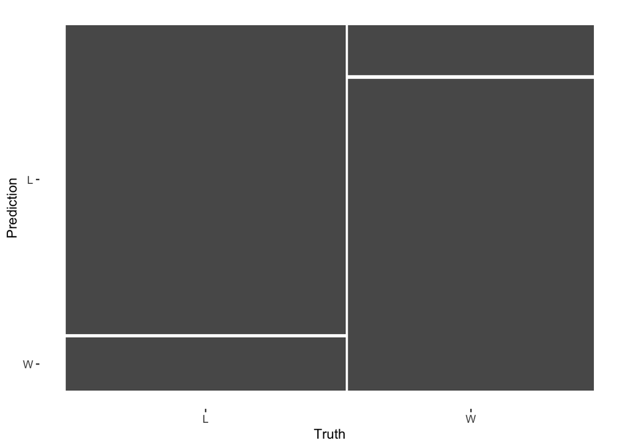

```r
in_sample_confusion %>%
  autoplot()
```

```r
summary(in_sample_confusion, event_level = "second") %>%
  filter(.metric == "accuracy")
```

```
# A tibble: 1 × 3
  .metric  .estimator .estimate
  <chr>    <chr>          <dbl>
1 accuracy binary         0.857
```

## Function

```r
# Access data from Mac Athletics website
vballdata <- function(year) {
  year <- as.character(year)
  url <- paste0("https://athletics.macalester.edu/sports/womens-volleyball/stats/", year)
  table <- read_html(url) %>%
    html_table() %>%
    .[[6]] %>%
    mutate(Opponent = str_extract(Opponent, "[A-Z].*")) %>% # remove "vs" and "at" from opponent name
    mutate(`W/L` = as.factor(`W/L`)) %>%
    filter(Date != "") %>%
    mutate(across(c(SA, SE, K, E, TA, AST, RE, DIG, BS, BA, BE, TB, BHE), ~ .x / SP)) # calculate per set stats (rather than raw totals)
  return(table)
}

vball2023 <- vballdata(2023) # example call

combineyears <- function(years) {
  data <- map_dfr(years, vballdata)
  return(data)
}

multyears <- combineyears(c(2021, 2022, 2023))
```

```r
# function for logistic regression model
vballmodel <- function(data) {
  data <- data %>%
    mutate(`W/L` = as.factor(`W/L`)) %>%
    mutate(`W/L` = relevel(`W/L`, ref = "L")) # reference is the 0

  logistic_spec <- logistic_reg() %>%
    set_mode("classification") %>%
    set_engine("glm")

  # NOT using SR Rating, we only have that data for 2024
  variable_recipe <- recipe(`W/L` ~ PCT + SA + SE, data = data)

  logistic_workflow <- workflow() %>%
    add_recipe(variable_recipe) %>%
    add_model(logistic_spec)

  logistic_model <- logistic_workflow %>%
    fit(data = data)
  tidy <- logistic_model %>%
    tidy()

  return(tidy)
}

vballmodel(multyears)
```

```
# A tibble: 4 × 5
  term        estimate std.error statistic  p.value
  <chr>          <dbl>     <dbl>     <dbl>    <dbl>
1 (Intercept)   -5.86      1.76     -3.32  0.000902
2 PCT           21.7       6.00      3.62  0.000300
3 SA             1.38      0.530     2.61  0.00911
4 SE             0.271     0.562     0.481 0.630
```